# Calculate Vapor Pressure Deficit of a Time Period

Hao-Ran Wu ( haoranwu @ zju.edu.cn )

2022-09-13

In this section we are concerned about how to calculate vapor pressure deficit (VPD) of a time period through the function `vpdeficit()`. Calculation of other variables related to VPD, including:

- Saturation vapor pressure
- Saturation vapor density
- Actual vapor density
- Actual vapor pressure
- Dew point temperature
- Wet-bulb temperature

is also shown in this section.

## Code Example(s)

```r
# Calculate Vapor Pressure Deficient for 22/09/2016 at Kellogg Biological Station
# *****************************************************************
#
# Calculate vapor pressure deficient (VPD). Data used in this example is collected
# in 2016 from Kellogg Biological Station (KBS), Michigan, USA (Zenone et al., 2011
# , 2013; Abraha et al., 2015, 2018).
#
# ********************************
# List of variables and units for this example
#
# 'path'        path of a CSV file, which conains four columns (with table titles)
#                * column 1: observation date. Required format "dd/mm/yyyy". Note
#                    that this variable is not required for calculating VPD
#                * column 2: hours of the day (h). Note that this variable is not
#                    not required for calculating VPD.
#                * column 3: hourly air temperature (Celsius). Note that air
#                    temperature must be above 0 Celsius.
#                * column 4: relative humidity (%). Valid range 0-100.
#
# Calculated variables in the program
#
# 'svp'         saturation vapor pressure (kPa)
# 'svd'         saturation vapor density (kg m-3)
# 'avd'         actual vapor density (kg m-3)
# 'avp'         actual vapor pressure (kPa)
# 'vpd'         vapor pressure deficit (kPa)
# 'dew'         dew point temperature (Celsius)
# 'wet'         wet-bulb temperature (Celsius)
#
# ********************************
# Step 1: import package
require(bproce)

# Step 2: choose parameters
path  <- "./data/1-2B Switchgrass Temperature Humidity.csv"

# Step 3: read data
dat   <- read.csv(path)       # read the CSV file
                              #  * column 1 ($date): observation date
                              #  * column 2 ($hour): hours of the day
                              #  * column 3 ($t_a): air temperature
                              #  * column 4 ($h): relative humidity
t_a   <- dat$t_a              # extract hourly air temperature
h     <- dat$h                # extract relative humidity

# Step 4: run the model
svp   <- satvp(t_a)           # calculate saturation vapor pressure
svd   <- satvd(t_a)           # calculate saturation vapor density
avd   <- actualvd(t_a, h)     # calcualte actual vapor density
avp   <- actualvp(t_a, h)     # calculate actual vapor pressure
vpd   <- vpdeficit(t_a, h)    # calculate vapor pressure deficit
dew   <- dewT(t_a, h)         # calculate dew point temperature
wet   <- wetbulbT(t_a, h)     # calculate wet-bulb temperature

res   <- data.frame(
  dat, svp=svp, svd=svd, avd=avd, avp=avp, vpd=vpd, dew=dew, wet=wet
)                             # calculated result
                              #  * column 1  ($date): observation date
                              #  * column 2  ($hour): hours of the day
                              #  * column 3  ($t_a): air temperature
                              #  * column 4  ($h): relative humidity
                              #  * column 5  ($svp): saturation vapor pressure
                              #  * column 6  ($svd): saturation vapor density
                              #  * column 7  ($avd): actual vapor density
                              #  * column 8  ($avp): actual vapor pressure
                              #  * column 9  ($vpd): vapor pressure density (VPD)
                              #  * column 10 ($dew): dew point temperature
                              #  * column 11 ($wet): wet-bulb temperature

# Step 5: show and visualize results
print(res, digits = 3)        # present the output

par(mfrow=c(2, 3))            # create a matrix of plots in one plotting space
plot(
  res$hour, res$svp, type = "l",
  xlab = "Hour", ylab = "Saturation vapor pressure"
)                             # plot saturation vapor pressure versus time
plot(
  res$hour, res$svd, type = "l",
  xlab = "Hour", ylab = "Saturation vapor density"
)                             # plot saturation vapor density versus time
plot(
  res$hour, res$avd, type = "l",
  xlab = "Hour", ylab = "Actual vapor density"
)                             # plot actual vapor density versus time
plot(
  res$hour, res$avp, type = "l",
  xlab = "Hour", ylab = "Actual vapor pressure"
)                             # plot actual vapor pressure versus time
plot(
  res$hour, res$vpd, type = "l",
  xlab = "Hour", ylab = "Vapor pressure deficit"
)                             # plot vapor pressure deficit versus time
plot(
  res$hour, res$dew, col=2, ylim=range(c(dew, wet)), type="l",
  xlab = "hour", ylab = "Temperature"
)                             # plot dew point temperature versus time
lines(res$hour, res$wet, col=3, type="l")
                              # plot wet-bulb temperature versus time
legend("right", pch=c(15, 15), col=c(2, 3), bty="n",
       legend=c("Dew point", "Wet-bulb")) # add legends
```

## Explanation

**Step1:** Load the package `bproce` through the `require()` function.

```r
require(bproce)
```

**Step2:** Choose model parameters.

```r
path  <- "./data/1-2B Switchgrass Temperature Humidity.csv"
```

**Step3:** Read data. Read the CSV file in table format and creates a data frame through the function `read.csv()`.

```r
dat <- read.csv(path)
head(dat)                     # print first parts of the data
```

```
        date hour  t_a    h
1 22/09/2016  0.0 14.7 97.0
2 22/09/2016  0.5 14.6 97.2
3 22/09/2016  1.0 14.8 97.7
4 22/09/2016  1.5 14.3 97.3
5 22/09/2016  2.0 14.7 98.1
6 22/09/2016  2.5 14.9 98.0
```

Then extract air temperatures and relative humidity from the data set.

```r
t_a   <- dat$t_a              # extract hourly air temperature
h     <- dat$h                # extract relative humidity
```

**Step4:** Run the model. The first step is to estimate saturation vapor pressure ($e_s$, kPa) from Tetens equation (Monteith and Unsworth, 2013):

$$e_s=0.6118e^{\frac{17.502T_a}{T_a+240.97}},\quad(1)$$
where $T_a$ is the air temperature above 0 <sup>o</sup>C.

```r
svp <- satvp(t_a)              # calculate saturation vapor pressure

print(head(data.frame(
  t_a = t_a, svp = svp
)), digits = 3)                # present the result
```

```
   t_a  svp
1 14.7 1.67
2 14.6 1.66
3 14.8 1.68
4 14.3 1.63
5 14.7 1.67
6 14.9 1.70
```

With known air temperature and $e_s$, saturation vapor density ($E_s$, kg m<sup>-3</sup>) can be calculated as:

$$E_s=\frac{e_s}{4.62×10^{-4}(T_a+273.15)},\quad (2)$$
Although $e_s$ should be estimated before computing $E_s$, function `satvd()` can automatically complete both tasks.

```r
svd <- satvd(t_a)              # calculate saturation vapor density

print(head(data.frame(
  t_a = t_a, svd = svd
)), digits = 3)                # present the result
```

```
   t_a  svd
1 14.7 12.6
2 14.6 12.5
3 14.8 12.7
4 14.3 12.3
5 14.7 12.6
6 14.9 12.7
```

With known relative humidity and $E_s$, actual vapor density ($E_a$, kg m<sup>-3</sup>) can be estimated as:

$$E_a=\frac{h·E_s}{100},\quad (3)$$
Similar to `satvd()`, function `actualvd()` is able to take equations (1–3) into the calculation of $E_a$ simultaneously. Therefore, the input arguments of `actualvd()` include both air temperature and relative humidity.

```r
avd <- actualvd(t_a, h)        # calculate actual vapor density

print(head(data.frame(
  t_a = t_a, h = h, avd = avd
)), digits = 3)                # present the result
```

```
   t_a    h  avd
1 14.7 97.0 12.2
2 14.6 97.2 12.2
3 14.8 97.7 12.4
4 14.3 97.3 11.9
5 14.7 98.1 12.3
6 14.9 98.0 12.5
```

Actual vapor pressure ($e_a$, kPa) is then calculate by the following equation:

$$e_a=\frac{(T_a+273.15)·E_a}{2170},\quad(4)$$

Calculation of $e_a$ via equations (1–4) can be done through the function `actualvp()`.

```r
avp <- actualvp(t_a, h)        # calculate actual vapor pressure

print(head(data.frame(
  t_a = t_a, h = h, avp = avp
)), digits = 3)                # present the result
```

```
   t_a    h  avp
1 14.7 97.0 1.62
2 14.6 97.2 1.61
3 14.8 97.7 1.64
4 14.3 97.3 1.58
5 14.7 98.1 1.64
6 14.9 98.0 1.66
```

With known $e_s$ and $e_a$, VPD can be calculated as the difference between these two variables:

$$VPD = e_s-e_a,\quad(5)$$

Function `vpdeficit()` can be used for computing VPD via equations (1–5).

```r
vpd <- vpdeficit(t_a, h)       # calculate vapor pressure deficit

print(head(data.frame(
  t_a = t_a, h = h, vpd = vpd
)), digits = 3)                # present the result
```

```
   t_a    h    vpd
1 14.7 97.0 0.0543
2 14.6 97.2 0.0507
3 14.8 97.7 0.0429
4 14.3 97.3 0.0481
5 14.7 98.1 0.0360
6 14.9 98.0 0.0381
```

```r
dew <- dewT(t_a, h)             # calculate dew point temperature

print(head(data.frame(
  t_a = t_a, h = h, dew = dew
)), digits = 3)                 # present the result
```

```
   t_a    h  dew
1 14.7 97.0 5.96
2 14.6 97.2 5.94
3 14.8 97.7 6.05
4 14.3 97.3 5.82
5 14.7 98.1 6.04
6 14.9 98.0 6.11
```

Wet-bulb temperature ($T_w$, oC) can be calculated by (Campbell and Norman, 2012):

$$T_w=\frac{e_a+\gamma·E_a·T_a}{e_s+\gamma·E_a},\quad (7)$$

where $\gamma$ is the thermodynamic psychometric constant, which is estimated by:

$$\gamma=\frac{C_p}{\lambda},\quad(8)$$

where $C_p$ is the specific heat of air (29.3 J mol<sup>-1</sup> <sup>o</sup>C<sup>-1</sup>) and $\lambda$ is the latent heat vaporization of water (40.660 kJ mol<sup>-1</sup>, or 2.260 kJ kg<sup>-1</sup>). Based on equation (1–4, 7–8), $T_w$ can be calculated through the function `wetbulbT()`.

```r
wet <- wetbulbT(t_a, h)          # calculate wet-bulb temperature

print(head(data.frame(
  t_a = t_a, h = h, wet = wet
)), digits = 3)                 # present the result
```

```
   t_a    h  wet
1 14.7 97.0 2.47
2 14.6 97.2 2.47
3 14.8 97.7 2.49
4 14.3 97.3 2.48
5 14.7 98.1 2.50
6 14.9 98.0 2.49
```

As discussed above, we have already computed $e_s$, $E_a$, $E_s$,$e_a$, VPD, $T_d$, and $T_w$ from air temperature and relative humidity. Now we can combine these results by columns and view them.

```r
res <- data.frame(
  dat, svp=svp, svd=svd, avd=avd, avp=avp, vpd=vpd, dew=dew, wet=wet
)
print(head(res), digits = 3)
```

```
        date hour  t_a    h  svp  svd  avd  avp    vpd  dew  wet
1 22/09/2016  0.0 14.7 97.0 1.67 12.6 12.2 1.62 0.0543 5.96 2.47
2 22/09/2016  0.5 14.6 97.2 1.66 12.5 12.2 1.61 0.0507 5.94 2.47
3 22/09/2016  1.0 14.8 97.7 1.68 12.7 12.4 1.64 0.0429 6.05 2.49
4 22/09/2016  1.5 14.3 97.3 1.63 12.3 11.9 1.58 0.0481 5.82 2.48
5 22/09/2016  2.0 14.7 98.1 1.67 12.6 12.3 1.64 0.0360 6.04 2.50
6 22/09/2016  2.5 14.9 98.0 1.70 12.7 12.5 1.66 0.0381 6.11 2.49
```

**Step5:** Save and visualize results. Use the `write.csv()` function to send outputs to a CSV file.

```r
write.csv(res,
          "./data/1-2B Calculate Vapor Pressure Deficit Output.csv",
          row.names = FALSE)
```

Create a line plot of calculated variables against time through the function `plot()`:

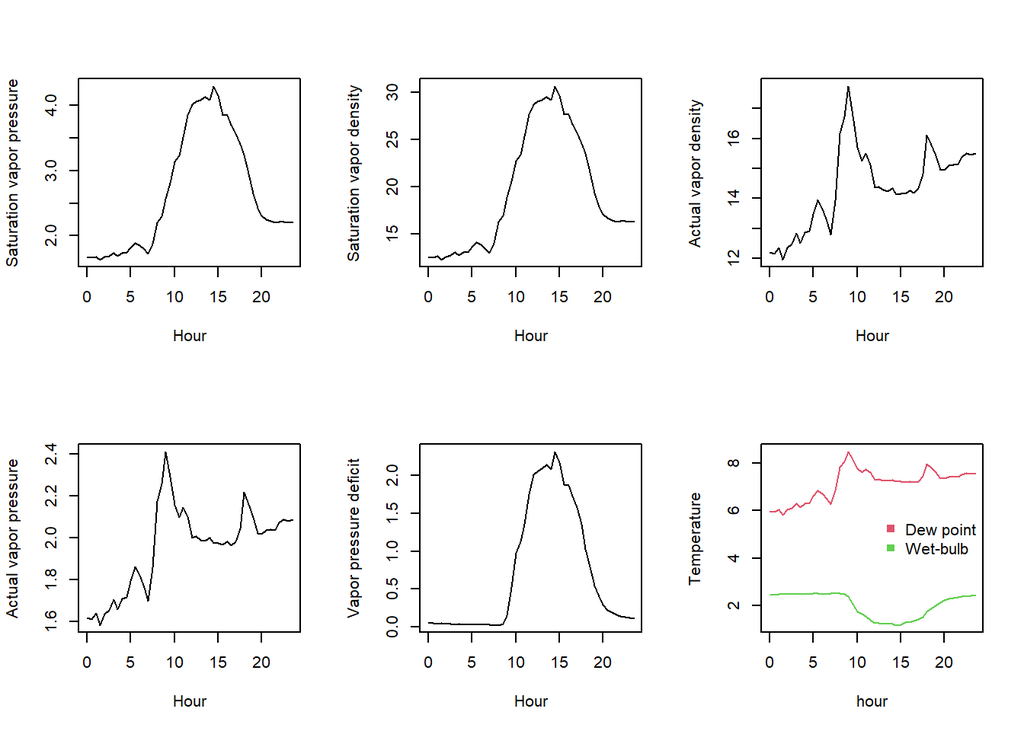

```r
par(mfrow=c(2, 3))            # create a matrix of plots in one plotting space
plot(
  res$hour, res$svp, type = "l",
  xlab = "Hour", ylab = "Saturation vapor pressure"
)                             # plot saturation vapor pressure versus time
plot(
  res$hour, res$svd, type = "l",
  xlab = "Hour", ylab = "Saturation vapor density"
)                             # plot saturation vapor density versus time
plot(
  res$hour, res$avd, type = "l",
  xlab = "Hour", ylab = "Actual vapor density"
)                             # plot actual vapor density versus time
plot(
  res$hour, res$avp, type = "l",
  xlab = "Hour", ylab = "Actual vapor pressure"
)                             # plot actual vapor pressure versus time
plot(
  res$hour, res$vpd, type = "l",
  xlab = "Hour", ylab = "Vapor pressure deficit"
)                             # plot vapor pressure deficit versus time
plot(
  res$hour, res$dew, col=2, ylim=range(c(dew, wet)), type="l",
  xlab = "hour", ylab = "Temperature"
)                             # plot dew point temperature versus time
lines(res$hour, res$wet, col=3, type="l")
                              # plot wet-bulb temperature versus time
legend("right", pch=c(15, 15), col=c(2, 3), bty="n",
       legend=c("Dew point", "Wet-bulb")) # add legends
```

## References

Abraha, M., Chen, J., Chu, H., Zenone, T., John, R., Su, Y. J., Hamilton, S. K., and Robertson, G. P. (2015). Evapotranspiration of annual and perennial biofuel crops in a variable climate. Global Change Biology-Bioenergy, 7(6), 1344–1356.

Abraha, M., Hamilton, S. K., Chen, J., and Robertson, G. P. (2018). Ecosystemcarbon exchange on conversion of Conservation Reserve Program grasslands to annual and perennial cropping systems. Agricultural and Forest Meteorology, 253, 151–160.

Campbell, G. S., and Norman, J. (2012). An Introduction to Environmental Biophysics. Springer Science & Business Media. 286pp.

Fritschen, L. J., and Gay, L. W. (1979). Environmental Instrumentation. Springer Science & Business Media. 216pp.

Monteith, J., and Unsworth, M. (2013). Principles of Environmental Physics: Plants, Animals, and the Atmosphere. Academic Press. 423pp.

Zenone, T., Chen, J., Deal, M. W., Wilske, B., Jasrotia, P., Xu, J., Bhardwaj, A. K., Hamilton, S. K., and Robertson, G. P. (2011). CO<sub>2</sub> fluxes of transitional bioenergy crops: Effect of land conversion during the first year of cultivation. Global Change Biology-Bioenergy, 3(5), 401–412.